# Assignment 5

Magee Ying

01/05/2022

```css
@import url('https://fonts.googleapis.com/css2?family=Hubballi&display=swap');
@import url('https://fonts.googleapis.com/css2?family=Anton&family=Hubballi&display=swap');

h1 {font-family: 'Anton', sans-serif;}
body {font-family: 'Hubballi', cursive;
      background-color: #c9c5c3}
```

## Introduction

For this assignment, I picked randomly 4 countries’ top 100 apple music playlists by using a die. I tried to find the number of explicit songs in the playlists across 4 different countries. I compared them and tried to obtain a result because it would be interesting to see if countries worldwide all prefer explicit songs.

## Visualisation

I’ve created the following graph as my visualisation:

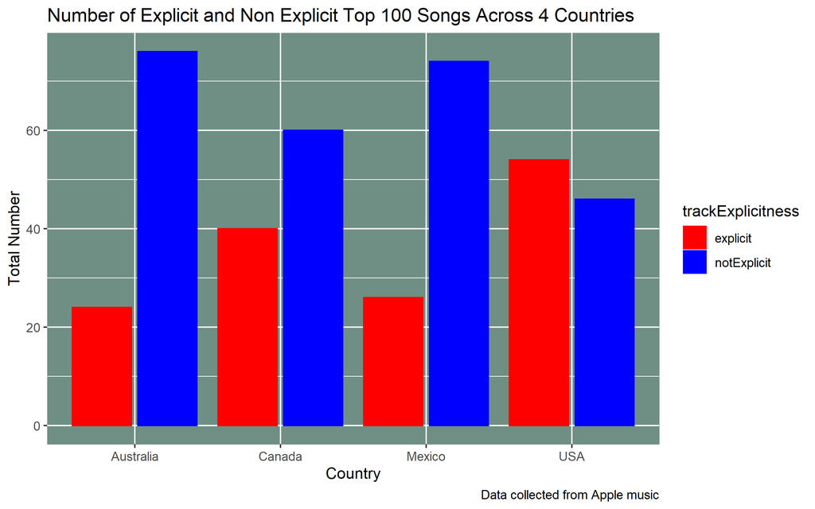

Data Plot

## Data creation

For this part of the assignment, I made the following gif:

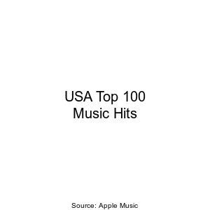

Gif

I have used skills from the package magick and tidyverse, with the usage of pipes, manipulating data frames, and proper image animation, I have created a gif which consists of the top playlist of the USA, where the title of the song comes after their ranking.

## Final reflection

For the module, I have learned that web scraping can be done by robots and manually, and we are able to do so as long as the HTML syntax of a page is well written. Web scraping can be extremely useful when we want to collect resources from online webpages, it would be more efficient if we have the right conditions applied to manipulate the contexts of HTML. We can then process the data in whatever way we need, such that it will provide access to the information we desire.

I believe taking stats 220 other than it’s a compulsory course, would benefit me in my data science career. As it trained me to gain strength and strong overall knowledge about data basis/application of R and SQL codes.

## Code appendix

```r
library(tidyverse)
library(rvest)

urls <- c("https://music.apple.com/us/playlist/top-100-australia/pl.18be1cf04dfd4ffb9b6b0453e8fae8f1",
          "https://music.apple.com/us/playlist/top-100-canada/pl.79bac9045a2540e0b195e983df8ba569",
          "https://music.apple.com/us/playlist/top-100-mexico/pl.df3f10ca27b1479087de2cd3f9f6716b",
          "https://music.apple.com/us/playlist/top-100-usa/pl.606afcbb70264d2eb2b51d8dbcfa6a12")


apple_data <- map_df(1:length(urls), function(i) {
  Sys.sleep(2)

  page <- read_html(urls[i])

  #Track Id
  trackId <- page %>%
    html_elements(".songs-list") %>%
    html_elements("a") %>%
    html_attr("href") %>%
    .[str_detect(., "/song/")] %>%
    str_remove_all("https://music.apple.com/us/song/")

  #Title
  title <- page %>%
    html_elements(".songs-list-row__song-name") %>%
    html_text2()

  #Rank
  rank <- page %>%
    html_elements(".songs-list-row__rank") %>%
    html_text2()

  return(tibble(trackId, title, rank))
})

saveRDS(apple_data, "apple_data.rds")
```

```r
library(tidyverse)
library(jsonlite)

apple_data <- readRDS("apple_data.rds")

trackIds <- apple_data$trackId %>%
  unique() %>%
  na.omit()

itunes_data <- map_df(1:length(trackIds), function(i) {
  Sys.sleep(2)
  song_id <- trackIds[i]
  url <- paste0("https://itunes.apple.com/lookup?id=", song_id)

  response <- fromJSON(url)
  data <- response$results

  return(tibble(data))
})

print(itunes_data)
saveRDS(itunes_data, "itunes_data.rds")
```

```r
library(tidyverse)

apple_data <- readRDS("apple_data.rds")
itunes_data <- readRDS("itunes_data.rds")

apple_data  <- apple_data %>%
  mutate(trackId = as.integer(trackId))

song_data = apple_data %>%
  inner_join(itunes_data, by = "trackId")

print(song_data)

saveRDS(song_data, "song_data.rds")
```

```r
library(tidyverse)
library(ggplot2)

song_data <- readRDS("song_data.rds")

data_au <- slice(song_data, 1:100) %>%
  mutate(country = "Australia")

data_canada <- slice(song_data, 101:200) %>%
  mutate(country = "Canada")

data_mex <- slice(song_data, 201:300) %>%
  mutate(country = "Mexico")

data_us <- slice(song_data, 301:400) %>%
  mutate(country = "USA")

song_data <- rbind(data_au, data_canada)
song_data <- rbind(song_data, data_mex)
song_data <- rbind(song_data, data_us)

data <- song_data %>%
  group_by(country = country) %>%
  count(trackExplicitness)

p <- ggplot(data, aes(x = country, y = n, group = trackExplicitness, color = trackExplicitness, fill = trackExplicitness)) +
  geom_col(position = "dodge2") +
  scale_fill_manual(values = c("explicit" = "red", "notExplicit" = "blue")) +
  scale_color_manual(values = c("explicit" = "red", "notExplicit" = "blue")) +
  theme(panel.background = element_rect(fill = "#6f8f84", color = "#6f8f84")) +
  labs(x = "Country", y = "Total Number", title = "Number of Explicit and Non Explicit Top 100 Songs Across 4 Countries", caption = "Data collected from Apple music")

ggsave("song_vis.png", width = 8, height = 5, units = "in")
```

```r
library(magick)
library(tidyverse)

data <- readRDS("song_data.rds")

us_data <- slice(data, 301:400)
us_data = select(us_data, -c(1))

animation <- image_blank(color = "white", width = 300, height = 300) %>%
  image_annotate(text = "USA Top 100\nMusic Hits", size = 20, gravity = "center") %>%
  image_annotate(text = "Source: Apple Music", size = 10, gravity = "south")

for (i in 1:nrow(us_data)) {
  img <- image_blank(color = "#4287f5", width = 300, height = 300) %>%
    image_annotate(text = paste0(i, ":\n", us_data[i, ]), size = 22, gravity = "center")

  animation <- c(animation, img)
}

animation <- image_animate(animation, fps = 1, dispose = "previous")

image_write(animation, "animation.gif")
```